# Most harmful event-types in the U.S.

Spongebob_77

8 November 2018

## Important note

Due to proxy related issues I couldn’t make the upload to RPubs. Also I couldn’t install LaTeX on the company computer. That’s why I upload the html doc.

## Synopsis

Based on the *Storm Data* from NOAA (U.S. National Oceanic and Atmospheric Administration’s) the main event-types shall be discovered with respect to population health and the economic consequences in the United States. The dataset contains information within a timeframe from 1950 till 2011. Due to reasons of data quality only the years 1992 till 2011 are used to answer the upper question. It turns out that tornados and lightnings are most harmful with respect to population health while floods, flashfloods and tornados cause the most economic damage.

## Data Preprocessing

### Libreries

First we load the libraries that are needed in this analysis.

```r
library(dplyr)
```

```r
library(ggplot2)
library(tidyr)
library(stringr)
```

### Read in Data

The data is in a *.csv.bz2* file which is read in here. The data can be downloaded on [Coursera](https://www.coursera.org/learn/reproducible-research/peer/OMZ37/course-project-2).

Then we check the dataset with respect to dimension, classes the variables have, and how the first few rows of the dataset look like.

```r
# Load the data
dat_orig <- read.csv("repdata%2Fdata%2FStormData.csv.bz2")
dat <- dat_orig

# check variables
dim(dat)
```

```
## [1] 902297     37
```

```r
str(dat)
```

```
## 'data.frame':    902297 obs. of  37 variables:
##  $ STATE__   : num  1 1 1 1 1 1 1 1 1 1 ...
##  $ BGN_DATE  : Factor w/ 16335 levels "1/1/1966 0:00:00",..: 6523 6523 4242 11116 2224 2224 2260 383 3980 3980 ...
##  $ BGN_TIME  : Factor w/ 3608 levels "00:00:00 AM",..: 272 287 2705 1683 2584 3186 242 1683 3186 3186 ...
##  $ TIME_ZONE : Factor w/ 22 levels "ADT","AKS","AST",..: 7 7 7 7 7 7 7 7 7 7 ...
##  $ COUNTY    : num  97 3 57 89 43 77 9 123 125 57 ...
##  $ COUNTYNAME: Factor w/ 29601 levels "","5NM E OF MACKINAC BRIDGE TO PRESQUE ISLE LT MI",..: 13513 1873 4598 10592 4372 10094 1973 23873 24418 4598 ...
##  $ STATE     : Factor w/ 72 levels "AK","AL","AM",..: 2 2 2 2 2 2 2 2 2 2 ...
##  $ EVTYPE    : Factor w/ 985 levels "   HIGH SURF ADVISORY",..: 834 834 834 834 834 834 834 834 834 834 ...
##  $ BGN_RANGE : num  0 0 0 0 0 0 0 0 0 0 ...
##  $ BGN_AZI   : Factor w/ 35 levels "","  N"," NW",..: 1 1 1 1 1 1 1 1 1 1 ...
##  $ BGN_LOCATI: Factor w/ 54429 levels "","- 1 N Albion",..: 1 1 1 1 1 1 1 1 1 1 ...
##  $ END_DATE  : Factor w/ 6663 levels "","1/1/1993 0:00:00",..: 1 1 1 1 1 1 1 1 1 1 ...
##  $ END_TIME  : Factor w/ 3647 levels ""," 0900CST",..: 1 1 1 1 1 1 1 1 1 1 ...
##  $ COUNTY_END: num  0 0 0 0 0 0 0 0 0 0 ...
```

[output cut: 23 more lines]

```r
head(dat)
```

```
##   STATE__           BGN_DATE BGN_TIME TIME_ZONE COUNTY COUNTYNAME STATE
## 1       1  4/18/1950 0:00:00     0130       CST     97     MOBILE    AL
## 2       1  4/18/1950 0:00:00     0145       CST      3    BALDWIN    AL
## 3       1  2/20/1951 0:00:00     1600       CST     57    FAYETTE    AL
## 4       1   6/8/1951 0:00:00     0900       CST     89    MADISON    AL
## 5       1 11/15/1951 0:00:00     1500       CST     43    CULLMAN    AL
## 6       1 11/15/1951 0:00:00     2000       CST     77 LAUDERDALE    AL
##    EVTYPE BGN_RANGE BGN_AZI BGN_LOCATI END_DATE END_TIME COUNTY_END
## 1 TORNADO         0                                               0
## 2 TORNADO         0                                               0
## 3 TORNADO         0                                               0
## 4 TORNADO         0                                               0
## 5 TORNADO         0                                               0
## 6 TORNADO         0                                               0
##   COUNTYENDN END_RANGE END_AZI END_LOCATI LENGTH WIDTH F MAG FATALITIES
```

[output cut: 20 more lines]

As we know now how the dataset looks like we can start with the preprocessing.

### Select years

First we have a look how sparse the data is. We might not consider data from the beginning of the tracking since it is written in the assignment that there was more data available from the later years.

```r
# extract year and save into new column "year"
dat$year <- as.numeric(str_sub(dat$BGN_DATE, -12, -8))

# plot the number of datapoints each year contains
no_datapoints_years <- dat %>% count(year)
no_datapoints_years
```

```
## # A tibble: 62 x 2
##     year     n
##    <dbl> <int>
##  1  1950   223
##  2  1951   269
##  3  1952   272
##  4  1953   492
##  5  1954   609
##  6  1955  1413
##  7  1956  1703
##  8  1957  2184
##  9  1958  2213
## 10  1959  1813
## # ... with 52 more rows
```

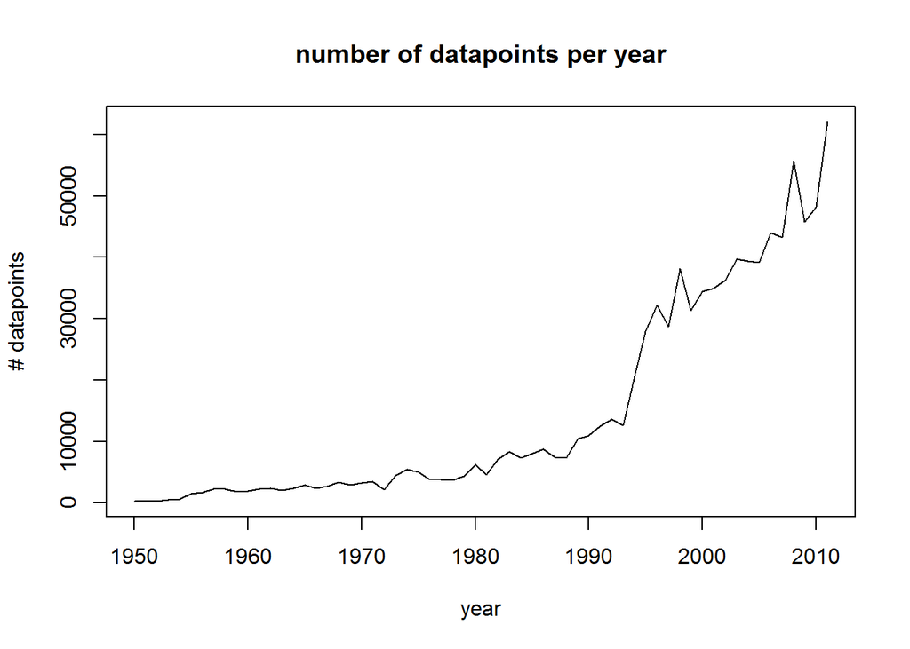

```r
plot(x = no_datapoints_years$year,
     y = no_datapoints_years$n,
     type = "l",
     main = "number of datapoints per year",
     xlab = "year", ylab = "# datapoints")
```

```r
# only keep the last twenty years of the data base
dat <- dat %>% filter(year >= 1992)
```

The data reaches from 1950 till 2011. In the first years the data was very sparse. So we decided to take into account only the last 20 years (1992-2011) in which period we consider the data base as sufficient.

### Select main events

The next step is to focus on the main event types - meaning the ones that occure the most. We assume that these events cause the most trouble with regard to population health and economic consequences. We take the variable *INJURIES* to determine the population health and *CROPDMG* to determine the economic consequences.

```r
# no. of types of events
length(unique(dat$EVTYPE))
```

```
## [1] 985
```

```r
# check number of occurences of types of events
no_occ_events <- as.data.frame(sort(table(dat$EVTYPE), decreasing = TRUE))
head(no_occ_events)
```

```
##                Var1   Freq
## 1              HAIL 232516
## 2         TSTM WIND 135420
## 3 THUNDERSTORM WIND  82563
## 4       FLASH FLOOD  54277
## 5           TORNADO  27292
## 6             FLOOD  25326
```

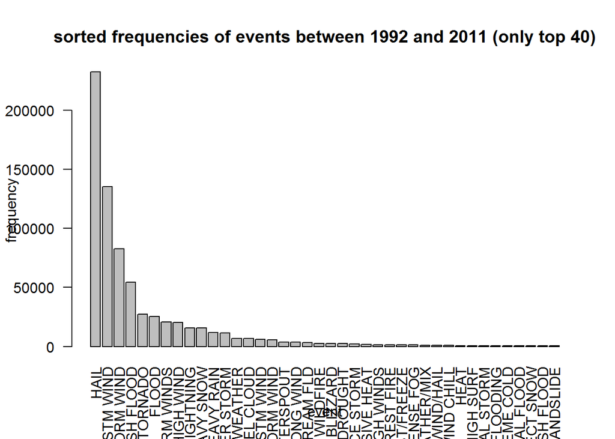

```r
# plot the top 40 events
barplot(sort(table(dat$EVTYPE), decreasing = TRUE)[1:40],
        las = 2,
        main = "sorted frequencies of events between 1992 and 2011 (only top 40)",
        xlab = "event", ylab = "frequency")
```

```r
# save types of events with occurrences >= 10k (main-events)
no_occ_events <- no_occ_events %>% filter(Freq >=10000)
main_events <- as.character(no_occ_events[, 1])
main_events
```

```
##  [1] "HAIL"               "TSTM WIND"          "THUNDERSTORM WIND"
##  [4] "FLASH FLOOD"        "TORNADO"            "FLOOD"
##  [7] "THUNDERSTORM WINDS" "HIGH WIND"          "LIGHTNING"
## [10] "HEAVY SNOW"         "HEAVY RAIN"         "WINTER STORM"
```

```r
# keep only data containing main-events
dat <- dat %>% filter(EVTYPE %in% main_events)
dim(dat)
```

```
## [1] 653067     38
```

```r
# only keep relevant variables with respect to health and consequences:
# envtype, injuries, cropdmg and year
rel_vars <- colnames(dat)[c(8, 24, 27, 38)]
dat_final <- dat[, rel_vars]
dim(dat_final)
```

```
## [1] 653067      4
```

It turned out that many of the events are written in different ways (e.g. *TSTM WIND* and *THUNDERSTORM WIND*). Since we only can make assumptions about which events could be unified it was decided to keep them seperated and to consider them as unequal events.

According to the upper barplot we decided to make the cut at 10k events since we only take a look at the events that occur the most. We end up with 12 events in total.

Now we have the final dataset *dat_final* which will be the base for the analysis.

### Formatting

In order to find out which types of events have the biggest effect on population and crop in the United States, we calculate the mean effects per event-type and year.

In the end we will be able to compare the means of all event-types over the years 1992 till 2011.

```r
# summarize by event-type and year for injuries and crop damages (means)
avgEffects <- dat_final %>% group_by(EVTYPE, year) %>%
                summarise(Injuries = round(mean(INJURIES), 3),
                          CropDamage = round(mean(CROPDMG), 3))

head(avgEffects)
```

```
## # A tibble: 6 x 4
## # Groups:   EVTYPE [1]
##   EVTYPE       year Injuries CropDamage
##   <fct>       <dbl>    <dbl>      <dbl>
## 1 FLASH FLOOD  1993    0.026      9.84
## 2 FLASH FLOOD  1994    0.028      5.26
## 3 FLASH FLOOD  1995    0.036      3.38
## 4 FLASH FLOOD  1996    0.014      4.51
## 5 FLASH FLOOD  1997    0.09       0.813
## 6 FLASH FLOOD  1998    0.116      2.23
```

```r
# wide to long format for results plot
avgEffects <- avgEffects %>% tidyr::gather(effectType, meanEffect, Injuries:CropDamage)

head(avgEffects)
```

```
## # A tibble: 6 x 4
## # Groups:   EVTYPE [1]
##   EVTYPE       year effectType meanEffect
##   <fct>       <dbl> <chr>           <dbl>
## 1 FLASH FLOOD  1993 Injuries        0.026
## 2 FLASH FLOOD  1994 Injuries        0.028
## 3 FLASH FLOOD  1995 Injuries        0.036
## 4 FLASH FLOOD  1996 Injuries        0.014
## 5 FLASH FLOOD  1997 Injuries        0.09
## 6 FLASH FLOOD  1998 Injuries        0.116
```

## Results

We produce a line plot splitted by crop damage (to detect economic consequences) and by injuries (to detect most harmful event-types for humans).

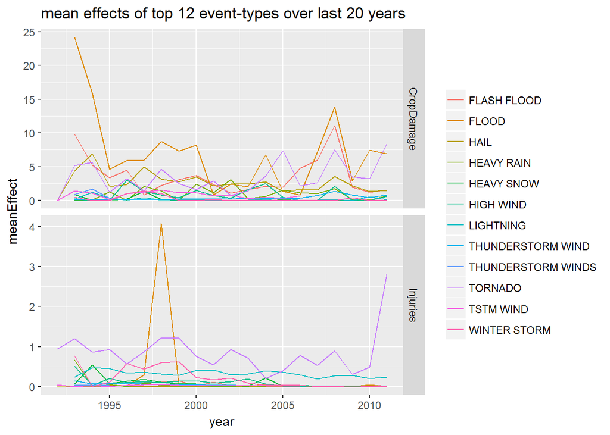

```r
# panel plot
avgEffects %>%
  ggplot(aes(x=year, y=meanEffect, colour=factor(EVTYPE))) +
  geom_line() +
  facet_grid(effectType ~ ., scales="free") +
  ggtitle("mean effects of top 12 event-types over last 20 years") +
  theme(legend.title = element_blank())
```

If we first take a look at the means from the crop damage we can see that floods have been the main cause in the past 20 years - especially in the early 90’s. In the years 2005 to 2011 we discover that crop damages were result mainly of floods, flash floods and tornados. Hail is another event that constantly have economic consequences, but way less than the other three events. So **floods, flash floods and tornados can be considered the as the greatest economic threads**.

In 1998 many people in the US were injured as a consequence of a flood. This was the most harmful event between 1992 and 2011. However, in the past few years tornados (especially in 2011) and lightnings have caused many injured people quite constantly. So **tornados and lightnings are the biggest threads to the people**.